# Your Digest for Wednesday, Oct 25, 2023 11:59 PM

# Ventilation and perfusion of the lung

> [!INFO] Ventilation and perfusion are **BOTH greater at the bases**  
> However, increase in blood (from top to bottom) is greater than the increase in ventilation (from top to bottom).  
> Therefore, overall, V/Q ratio *decreases* from top to bottom.

> In a healthy individual, the *V/Q ratio is 1 at the middle of the lung*, with a minimal spread of V/Q ratios from 0.3 to 2.1 from base to apex. [Source](https://www.ncbi.nlm.nih.gov/books/NBK539907/)

**Ventilation**:  
Less negative intrapleural pressure at the base -> lower transmural difference at the base -> Basal alveoli are less expanded -> Therefore, they are more compliant -> Therefore, large change in volume during inspiration -> **bases have higher ventilation**.

**Perfusion**:  
Perfusion is also *greater at the bases.*

> [!INFO] These are usually attributed to gravity  
> because these variations decrease in the supine position.  
> However, they are still present in weightlessness of space.

## Possible effect of V/Q ratio on alveolar PO2

> In cases of **high V/Q ratios, PO2 increases and PCO2 decreases** as *alveolar air more closely matches the larger volume of inspired air* than perfused blood. On the other hand, **low V/Q ratios result in a decreased PO2** and an increased PCO2. [Source](https://www.ncbi.nlm.nih.gov/books/NBK539907/)  
> So ? alveolar PO2 would be higher at the top and lower at the bottom of the lung.

# Pulmonary vascular resistance

Pulmonary mean arterial pressure = 15mmHg.  
Mean pulmonary venous pressure (= LAP = wedge pressure) = 5mmHg.

[figure not shown]

> [!INFO] How to rember:  
> PA = alveolar;  
> Pa - arterial, Pv - venous  
> The position of PA progressively moves to the right side of the comparison; it becomes lower and lower relative to the vascular pressures.

The lower the alveolar pressures, the less distended they are -> less pressure on the vessels -> less vascular resistance.  
**Vascular resistance is lowest in zone 3 and HIGHEST IN ZONE 1** [Source](https://www.ncbi.nlm.nih.gov/books/NBK554380/)

# Effect of anatomic dead space

Rapid breathing at low tidal volume and slow breathing at large tidal volume both result in the same minute ventilation.  
But because of anatomical dead space, with rapid shallow breathing, less air *reaches the alveoli* resulting in **significantly less alveolar ventilation**.

# Cardiac tamponade

#2018BSQ-OCT/Q13  
The normal pericardium can stretch to accommodate physiologic changes in cardiac volume but once this 'reserve' is occupied, the pericardium stiffens up.  
In tamponade, there is greatly increased interventricular dependence.

In inspiration, venous return increases but the RV can't expand so the septum bulges into the LV reducing LV volume -> decreased LV filling -> possible mechanism of *pulsus paradoxus*

Subacute to chronic effusions can be as large as 2L before symptoms occurs due to pericardial stretching.  
Acute effusions are usually due to some type of bleeding -> acute -> symptomatic at low volumes.

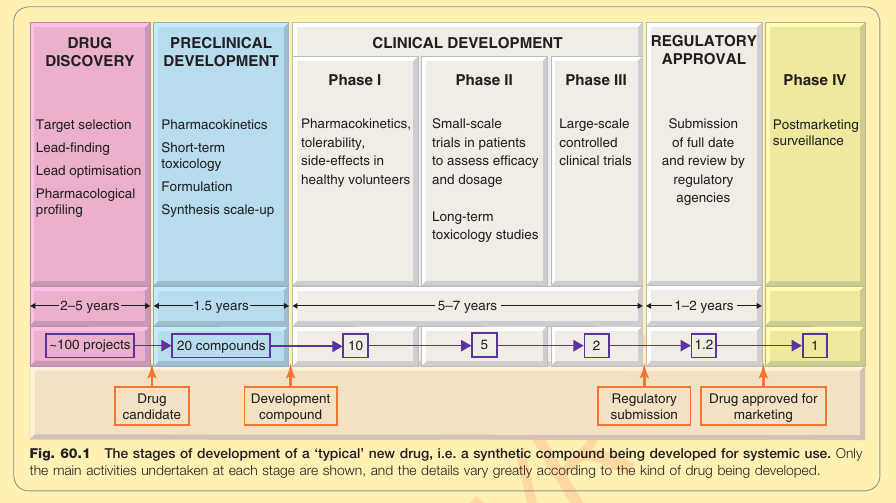

> Phase 2 = 100-300 *patients* to assess efficacy and dosage. (pharmacokinetics and dynamics, dose ranges, efficacy and safetly)  
> Phase 3 = 1000-3000 to confirm effectiveness, monitor side effects and *compare with other treatments*. (therapeutic confirmation - Randomized controlled trials; efficacy, safety)

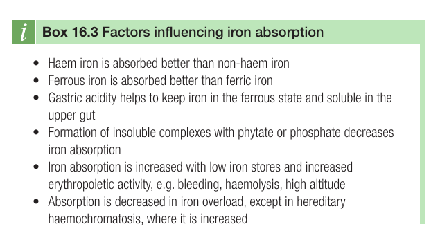

Most dietary iron is in the Ferric Fe3+ form but absorption requires the Fe2+ forms. Therefore, brush border has ferric reductase enzyme. Gastric acid is required for iron to for complexes with *ascorbic acid* so that it can be reduced.  
Partial gastrectomy therefore causes iron deficiency.

> Iron *elimination* is a zero order process. Which is probably why [[2021 General Medicine July#Iron FESO4 / sulphate overdose]] causes toxicity.

## Cholinergic crisis

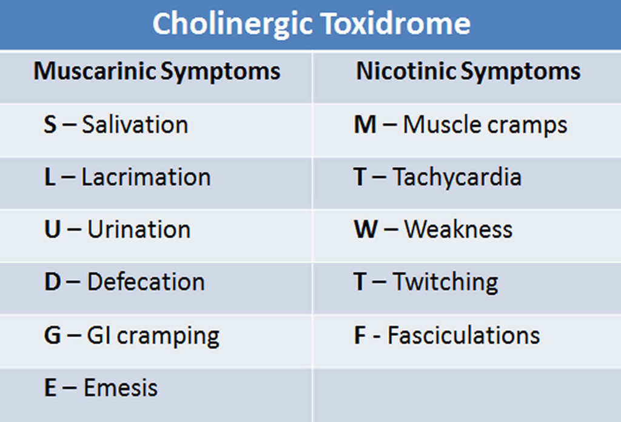

Cholinergic hyperstimulation secondary to inhibition of acetylcholinesterase enzyme.  
Symptoms: hypersalivation, lacrimation, muscle weakness, paralysis, blurry vision due to both nitocinic and muscarinic toxicity.

#2018BSQ-OCT/Q16  
Reprogramming of stem cells to differentiate into a cell type that is more suitable to cope with the new stresses than the original cell type at that location. Can occur in *epithieal* OR *mesenchyal* cells.  
Example: **Squamous metaplasia** of *respiratory epithelium in smokers.*  
#2018BSQ-OCT/Q16

- *Mainly seen in epithelial lesions*.
  - **Pleomorphism** with large, hyperchromatic nuclei.
  - *Increased mitotic count* with mitoses in unusual areas (i.e away from basement membrane)
- However, mild to moderate dysplasia *can spotaneously regress* as well.

Normally soluble proteins are deposited extracellularly as beta pleted fibrils.

> **AL amyloidosis** must be differentiated from other forms of amyloidosis (eg, AA amyloidosis, ATTRmt amyloidosis, and ATTRwt amyloidosis) since the *latter are non-neoplastic and will not benefit from chemotherapy.*  
> When **Congo red stains** binds to amyloid protein, it produces *apple green birefringence*.
- purpura, petechiae, and ecchymoses following minor trauma ("*pinch purpura*")
- Appearance of *periorbital purpura* following a Valsalva maneuver or dependent positioning of the head.(Racoon eyes)
- *Macroglossia* ([picture 16](https://www.uptodate.com/contents/image?imageKey=DERM%2F65060&topicKey=DERM%2F7606&source=see_link)), waxy papules and plaques, *enlarged shoulder pads*, bullous lesions, and sclerodermatous changes in the skin may also be seen. (UpToDate)

#### 📑Symptoms and signs

> Seen in Chronic inflammatory disorders include rheumatoid arthritis, inflammatory bowel disease and untreated familial Mediterranean fever.

Treatment of the underlying condition can control but not cure amyloidosis.  
**For transthyretin type** amyloidosis, liver transplant is definitive therapy as the liver is where transthyretin is made.

### 📑Phenytoin side effects

> Extraction ratio for *all drugs* decreases with increasing hepatic flow.

| Low extraction ratio drugs | High extraction ratio drugs |
| --- | --- |
| Flow independent | Flow dependent |
| Warfarin, phenytoin | Morphine, GTN, propranolol, verapamil |
|  | Lignogaine |

# Efficacy and potency

#2018BSQ-OCT/Q02  
**Efficacy** is the maximum effect that a drug can exert.  
**Potency** is the concentration/dose of drug required to exert 50% of it's maximal effect.  
[Source](https://derangedphysiology.com/main/cicm-primary-exam/required-reading/pharmacodynamics/Chapter%20415/potency-and-efficacy)

## Efficacy:

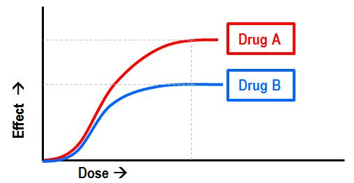

A has higher *efficacy* than B.  
But the dose at which 50% of maximum drug effect is achieved for Both A and B are similar. (?so similar potency?)

### Therapeutic efficacy and pharmacological efficacy

The concept above is therapeutic efficacy.  
Pharmacological efficay (also called Intrinsic efficacy) is

> is the drug's maximal efficacy as a fraction of the maximal efficacy produced by a full agonist of the same type acting through the same receptors under the same conditions

## Potency

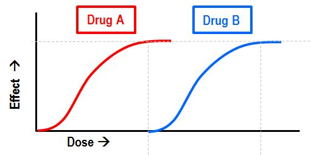

A and B have the same maximum effect (i.e same efficacy) but A achieves this at a lower dose; Therefore, **A is more potent.**

#2018BSQ-OCT/Q15

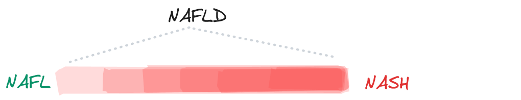

> [!INFO] TIP: NALF is not NALFD  
> NALF is the mild end of NAFLD; NALFD is a collective term

*Histologically looks like alcoholic liver disease* but patient does not have a Hx of significant alcohol consumption.

> [!WARNING] NASH progresses to cirrhosis in 20% of patients!
- Central obesity
- type 2 diabetes mellitus
- dyslipidemia,  
  NALFD is considered to be the hepatic component of metabolic syndrome.

### 📑Pathophysiology of NAFLD

📑Insulin resistance is the key prerequisite for NAFLD.

> *Insulin resistance* leads to **increased lipolysis**, triglyceride synthesis, **increased hepatic uptake of free fatty acids (FFA)**, and accumulation of hepatic triglyceride

Oxidative stress may then lead to **lipid peroxidation**.

#### Histology of NAFL (and alcoholic liver disease)

3 main changes occurring in various degrees and combinations:

- **Steatosis** (fatty change), **Hepatitis** (inflammation) and **Fibrosis**

**Steatosis**:  
Starts with fat accumulation in centrilobular areas and *then spreads outwards*. The liver will be soft, yellow and greasy. (i.e *starts in ZONE 3*)

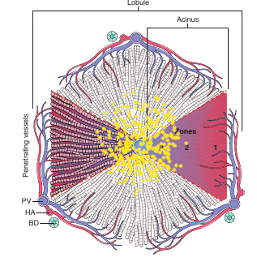

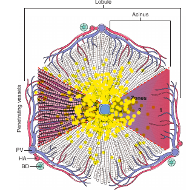

**Steatohepatitis**  
This stage is more common in alcoholic hepatitis than NAFL.  
Shows

- Hepatocyte ballooning with necrosis
- Intracellular eosinophilic includions: *Mallody Denk bodies*
- *Neutrophil infiltration* to remove the necrotic hepatocytes and those with Mallory Denk bodies.

**Fibirosis**

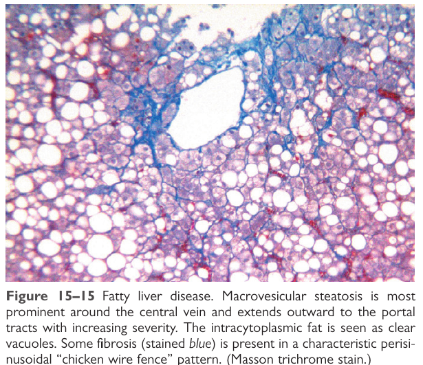

- Also appears in zone 3 and spread outwards. (*central vein sclerosis*)
- Perisinusoidal scarring in space of disse also similary spreads outwards
- Fibrosis spreads in *chicken wire fence pattern*
- The fibrosis reach the protal tracts and creates **central-portal** fibrous septa.
- These changes cause **micronodular cirrhosis.** (aka **Laennec cirrhosis**)
- Chronically, the liver becomes shrunken but with cirrhotic *nodules which are smaller than in other causes* like viral hepatitis.

### Investigations

- Mild increases in ALT and AST with ALT > AST; mild elevation of *gamma-GT*.
- USS Shows steatosis
- Biopsy : not necessary
- Elastography - to evaluate degree of fibrosis.
- Lifestyle advice aimed at weight loss with excercise and dieting.
- Orlistat (enteric lipase inhibitor) is used as adjunct in severely obese to reduce intestinal lipid absorption
- Can cause vitamin malabsorption.
- Pioglitazone has been proven to reduce NASH but weight gain CCF, bladder cancer and fracture risk are increased.

# Morphology of hepatitis

Acute hepatitis leads to significant destruction with less inflammation.  
In Chronic hepatitis, there is more inflammation than destruction.

> [!INFO] In acute AND chronic hepatitis, ❗mononulear cells (macrophages) predominate.❗  
> There is no neutrophil Vs. macrophage predominance in acute Vs. chornic hepatitis like in most orther tissues.

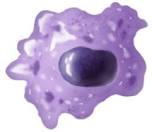

## Acute hepatitis

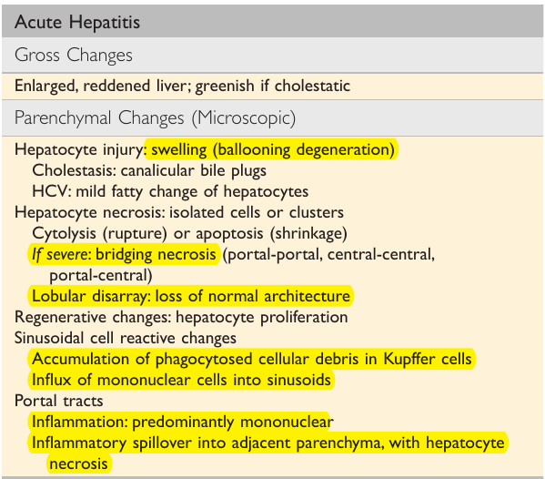

- Necrotic areas macroscopically have a mushy texture and muddy color.
- *Less inflammation*, **more hepatocyte death**
- Two forms of cell death are
  - **Necrosis** - cells undergo *ballooning degeneration* (cytoplasm looks empty) -> then cytolysis occurs and cells appear to have *dropped out*, their existence only being marked by the mourning macrophages left behind and the reticulin scaffhold.

[figure not shown]

## Chronic hepatitis

- Features nodules and scarring.
- **More inflammation**, *less death*
- There are *dense, mononuclear **portal** infiltrates*. <-❗ defining lesion of chronic hepatitis❗
- There is **interface hepatitis** -> (spillover from portal inflammation) unlike lobular hepatitis above, the ?necroris occurs at the parenchyma/ portal stroma interface.
- Fibrosis occurs: First only within portal tracts but then **between portal tracts** forming *fibrous septa.* -> Together with nodule formation, this leads to cirrhosis.

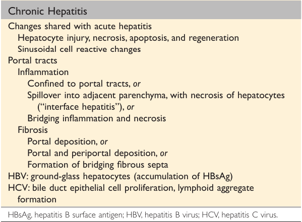